# CoronaBR Markdown

Fellipe Porto

22/12/2020

Pessoal, vamos verificar como tudo que aprendemos pode nos ajudar a analisar os dados sobre coronavirus no Brasil. Usarei uma adaptação de “Analise de Dados COVID-19 de Jean Jesus”.

Os dados estão disponíveis em: https://covid.saude.gov.br/

Primeiro, vamos carregar os pacotes que utilizaremos.

Pacotes utilizados:

```r
setwd('D:/R/estudoR/covid19_R/homework6_coronaBR')

library(dplyr)     # Manipulação de dados
```

```r
library(tidyr)     # Manipulação de dados
library(ggplot2)   # Criação de graficos
library(readxl)     #Leitura de arquivos em Excel
library(patchwork)  #Subplots
library(scales)     #trabalhar com escalas nos gráficos
```

Salve os dados e transfira para o R. Abaixo os comandos.

```r
corona = read_excel("HIST_PAINEL_COVIDBR_15jun2020.xlsx",
                                            col_types = c("text",    # Regiao
                                                          "text",    # Estado
                                                          "text",    # Municipio
                                                          "text",    # coduf
                                                          "numeric", # codmun
                                                          "numeric", # codRegiaoSaude
                                                          "text",    # nomeRegiaoSaude
                                                          "date",    # data
                                                          "numeric", # semanaEpi
                                                          "text",    # populacaoTCU2019
                                                          "numeric", # casosAcumulado
                                                          "numeric", # casosNovos
                                                          "numeric", # obitosAcumulado
                                                          "numeric", # obitosNovos
                                                          "numeric", # Recuperadosnovos
                                                          "numeric"  # emAcompanhamentoNovos
                                                          ))
```

Vamos olhar nosso banco de dados usando head:

```r
head(corona)
```

```
## # A tibble: 6 x 16
##   regiao estado municipio coduf codmun codRegiaoSaude nomeRegiaoSaude
##   <chr>  <chr>  <chr>     <chr>  <dbl>          <dbl> <chr>
## 1 Brasil <NA>   <NA>      76        NA             NA <NA>
## 2 Brasil <NA>   <NA>      76        NA             NA <NA>
## 3 Brasil <NA>   <NA>      76        NA             NA <NA>
## 4 Brasil <NA>   <NA>      76        NA             NA <NA>
## 5 Brasil <NA>   <NA>      76        NA             NA <NA>
## 6 Brasil <NA>   <NA>      76        NA             NA <NA>
## # ... with 9 more variables: data <dttm>, semanaEpi <dbl>,
## #   populacaoTCU2019 <chr>, casosAcumulado <dbl>, casosNovos <dbl>,
## #   obitosAcumulado <dbl>, obitosNovos <dbl>, Recuperadosnovos <dbl>,
## #   emAcompanhamentoNovos <dbl>
```

Nosso primeiro objetivo é fazer um gráfico de mortes por região. Para isso, vamos excluir toda a informação referente ao Brasil (que é o total). Para fazer isso, vamos usar filter para criar um novo conjunto de dados chamada coronaregiao.

```r
coronaregião=filter(corona, !is.na(corona$estado)& is.na(corona$municipio))
head(coronaregião)
```

```
## # A tibble: 6 x 16
##   regiao estado municipio coduf codmun codRegiaoSaude nomeRegiaoSaude
##   <chr>  <chr>  <chr>     <chr>  <dbl>          <dbl> <chr>
## 1 Norte  RO     <NA>      11        NA             NA <NA>
## 2 Norte  RO     <NA>      11        NA             NA <NA>
## 3 Norte  RO     <NA>      11        NA             NA <NA>
## 4 Norte  RO     <NA>      11        NA             NA <NA>
## 5 Norte  RO     <NA>      11        NA             NA <NA>
## 6 Norte  RO     <NA>      11        NA             NA <NA>
## # ... with 9 more variables: data <dttm>, semanaEpi <dbl>,
## #   populacaoTCU2019 <chr>, casosAcumulado <dbl>, casosNovos <dbl>,
## #   obitosAcumulado <dbl>, obitosNovos <dbl>, Recuperadosnovos <dbl>,
## #   emAcompanhamentoNovos <dbl>
```

Agora precisamos criar a variável mortesPorRegião:

```r
mortesPorRegiao <- coronaregião %>%
  select(regiao, obitosNovos) %>%
  group_by(regiao) %>%
  summarise(total = sum(obitosNovos))
```

E finalmente o gráfico:

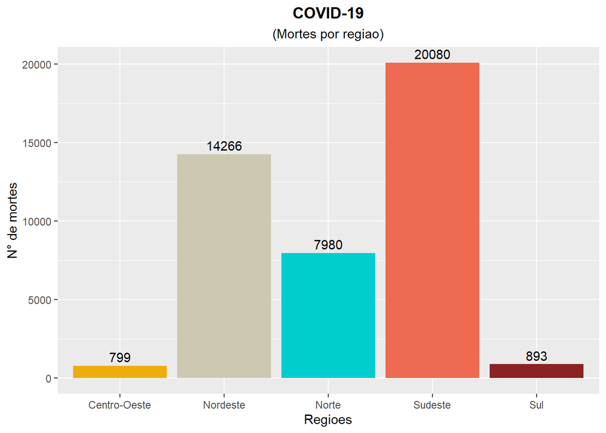

```r
ggplot(mortesPorRegiao, aes(x = regiao, y = total ))+
  geom_bar(stat = "identity", aes(fill = regiao))+
  scale_fill_manual(values=c("darkgoldenrod2", "cornsilk3", "cyan3","coral2","brown4"))+
  labs(
    title = "COVID-19",
    subtitle = "(Mortes por regiao)",
    x = "Regioes",
    y = "N° de mortes",
    face = "bold"
  )+
  geom_text(aes(label = total, vjust = -0.4) )+
  theme(
    plot.title = element_text(hjust = 0.5, face = "bold"),
    plot.subtitle = element_text(hjust = 0.5),
    legend.position = "none"
  )
```

Agora nosso objetivo é conhecer os 5 estados mais afetados com base no total de casos.

```r
top5estados <-   coronaregião %>%
  select(estado, casosNovos) %>%
  group_by(estado) %>%
  summarise(total_casos = sum(casosNovos)) %>%
  arrange(desc(total_casos))
# realização do rank 5
top5estados <- top_n(top5estados, 5)
```

Agora o gráfico:

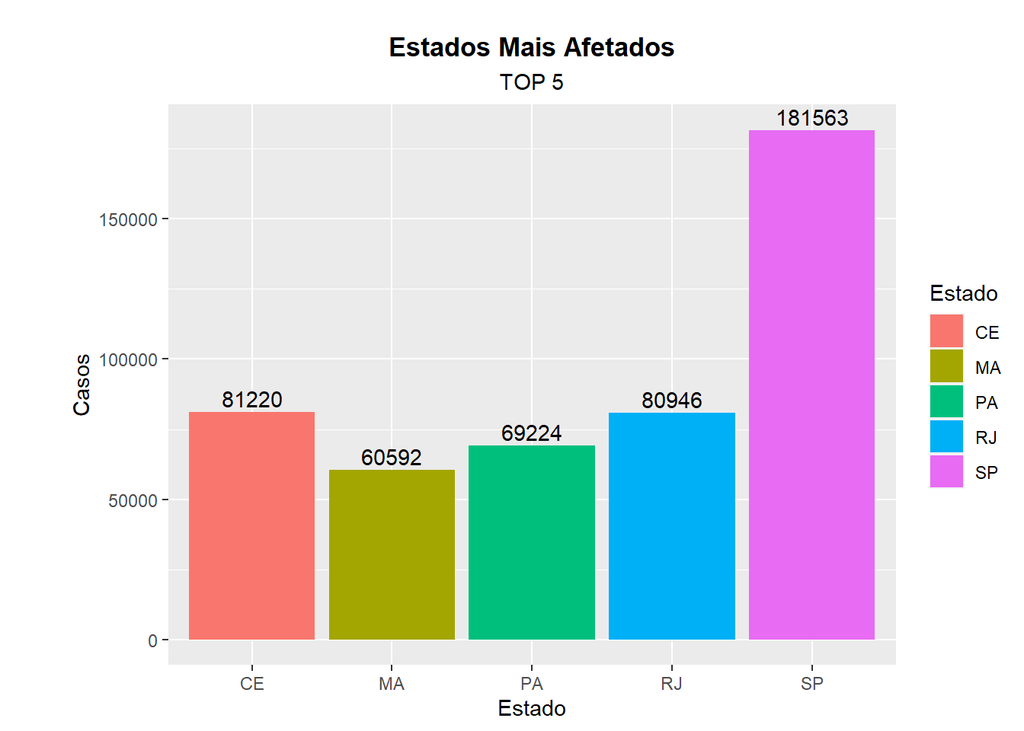

```r
ggplot(top5estados, mapping = aes(x = estado, y = total_casos))+
  geom_bar(stat = "identity", aes(fill = estado))+
  labs(
    title = "Estados Mais Afetados",
    subtitle = "TOP 5",
    x = "Estado",
    y = "Casos",
    tag = "        "
  )+
  geom_text(aes(label = total_casos, vjust = -0.3) )+
  theme(
    plot.title = element_text(hjust = 0.5, face = "bold"),
    plot.subtitle = element_text(hjust = 0.5)
  )+  scale_fill_discrete(name = "Estado")
```

Vamos avaliar a evolução do número de novos casos no Brasil. Vamos olhar os dados agregados para o Brasil e treinar o uso de filter mais uma vez. Para isso, vamos excluir todos os dados relativos aos estados e municípios. Além disso, vamos retirar as colunas que não nos interessam (usamos select com o sinal de - para fazer isso.)

```r
corona_Brasil <- corona%>%
  filter(is.na(estado), is.na(codmun)) %>%
  select(-estado, -municipio, -codmun, -codRegiaoSaude, -nomeRegiaoSaude,
         -coduf)
```

Agora basta fazer o gráfico usando a coluna de casosAcumulados:

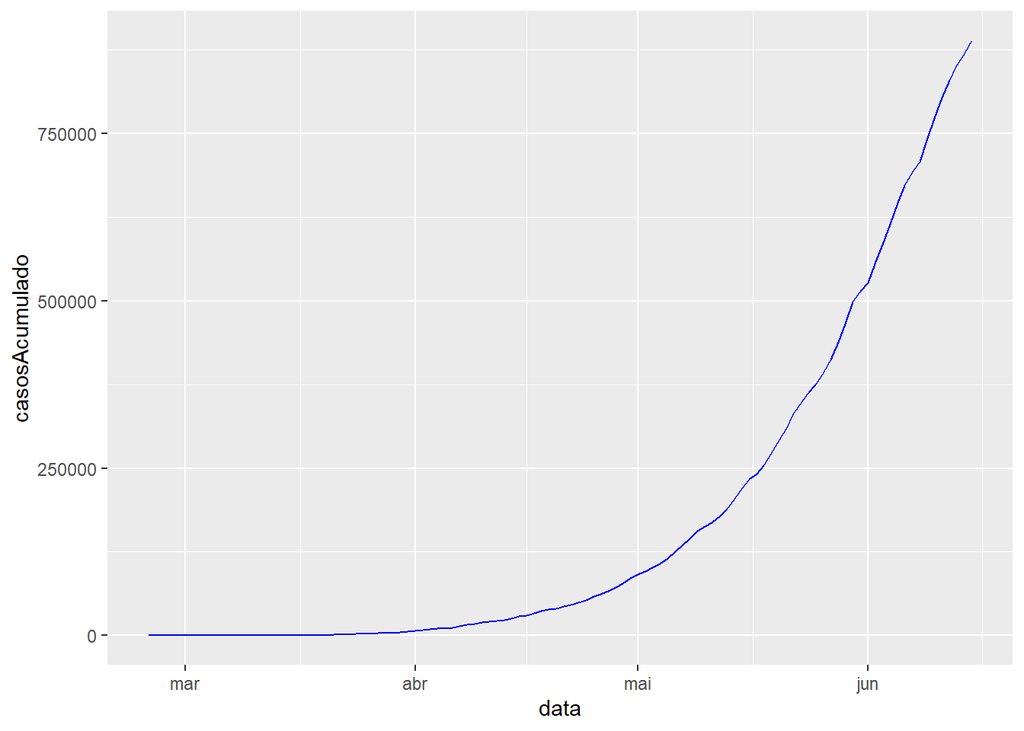

```r
acumuladoBR=ggplot(corona_Brasil, aes(data, casosAcumulado)) +
  geom_line(color="blue")
acumuladoBR
```

Agora o número de óbitos novos:

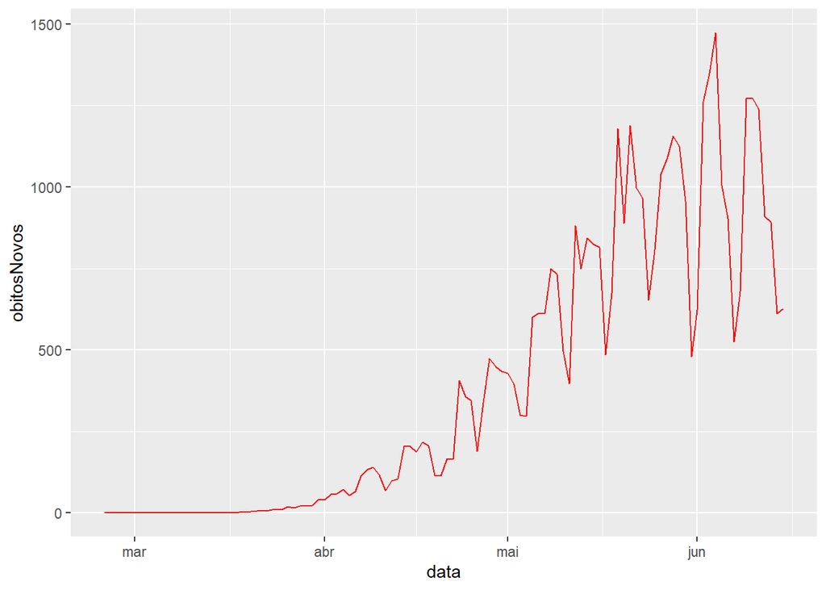

```r
newdeaths=ggplot(corona_Brasil, aes(data, obitosNovos)) +
  geom_line(color="red")
newdeaths
```

Óbitos Acumulados:

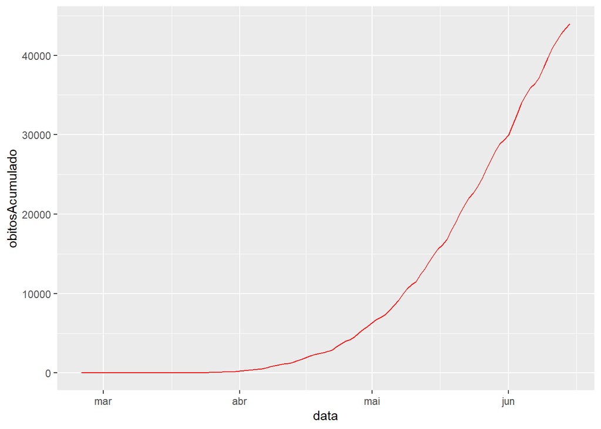

```r
deathsAc=ggplot(corona_Brasil, aes(data, obitosAcumulado)) +
  geom_line(color="red")
deathsAc
```

E por fim, podemos avaliar o número de novos casos por dia no Brasi:

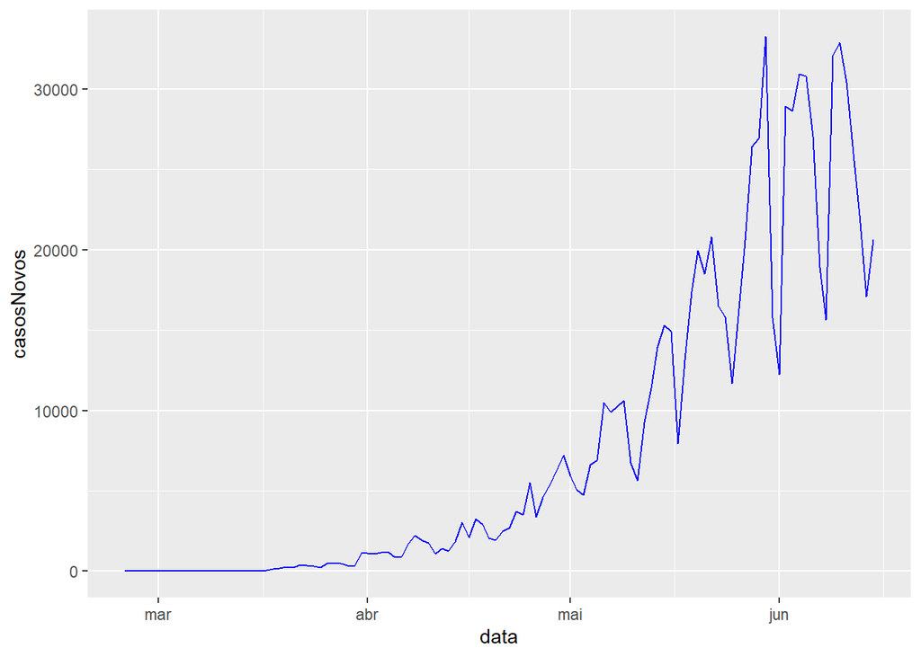

```r
newcases=ggplot(corona_Brasil, aes(x = data, y = casosNovos)) +
  geom_line(color="blue")
newcases
```

Para colocar os gráficos em subplots vamos usar o pacote patchwork dessa vez.

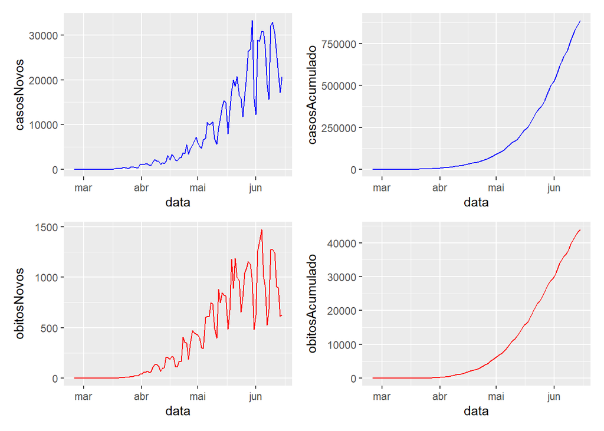

```r
newcases + acumuladoBR + newdeaths+deathsAc
```

Registro também como podemos selecionar apenas um estado (por exemplo, o estado de SP):

```r
estado_SP=corona %>%
  filter(!is.na(estado), is.na(codmun), estado=="SP")
```

Para selecionar apenas os municípios:

```r
municípios=municipios <- corona %>%
  filter(!is.na(estado), !is.na(municipio))
```

E um município apenas, por exemplo, Sorocaba:

```r
Sorocaba=municipios <- corona %>%
  filter(!is.na(estado), !is.na(municipio), municipio=="Sorocaba")
```

Para finalizar, vamos fazer um gráfico com os óbitos acumulados de todos os estados. Primeiro, vamos filtrar por estado e depois usar ggplot para obter o gráfico. Note que temos um problema de escala, pois enquanto alguns estados tem muitos óbitos, outros tem menos. Para contornar isso, iremos usar o pacote o pacote scales para fazer a escala livre em cada subplot. Vamos lá.

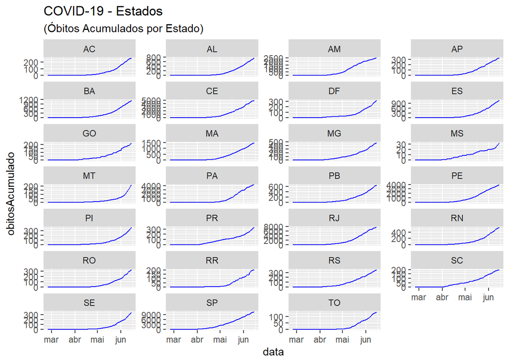

```r
corona_estados = corona %>%
  filter(!is.na(estado), is.na(codmun))

ggplot(corona_estados, aes(data, obitosAcumulado)) +
  geom_line(color="blue") +
  facet_wrap(vars(estado), ncol = 4, scales = "free_y")+
  labs(
    title = "COVID-19 - Estados",
    subtitle = "(Óbitos Acumulados por Estado)"
    )
```